# Coursera: Johns Hopkins Data Science Capstone - Milestone Report

Travis May

# Introduction:

The purpose of this milestone report is to indicate that I am sufficiently capable of handling large data sets within the R framework. The data set that I will use is a corpora of curated text from various blogs, news sites, and twitter posts, or ‘tweets’. I will apply this data set to a text prediction algorithim which will be compiled into a Shiny application in the second half of the course.

The remaining sections of this report will first explain how I extract and clean the data, and then present the analysis of data required for successful implementation of the text prediction app.

# The Data:

The HC Corpora is sourced as provided by the course instructors. The data is located at http://d396qusza40orc.cloudfront.net/dsscapstone/dataset/Coursera-SwiftKey.zip. More detailed information about the corpora at http://www.corpora.heliohost.org/aboutcorpus.html.

## Data Processing

The corpora is available in multiple languages, but for the purposes of this project I will only use the files in US English.

### Download

```r
fileURL <- "http://d396qusza40orc.cloudfront.net/dsscapstone/dataset/Coursera-SwiftKey.zip"
download.file(fileURL, destfile = "Dataset.zip", method = "curl")
unlink(fileURL)
unzip("Dataset.zip")
```

### Read into Environment

#### The function:

```r
loader <- function(item) {

    if(tools::file_ext(item)=='txt') {

      # Import 'News' data in binary mode
      if(grepl('news',item)) {
        con <- file(paste('./final/en_US/',item,sep = '/'),open='rb')
        l <- readLines(con, encoding='UTF-8')
        close(con)
        rm(con)
      }
      # Import 'Twitter' and 'Blog' data in text mode
      else {
        l <- readLines(paste('./final/en_US/',item,sep = '/'),skipNul = TRUE,warn = FALSE, encoding = 'UTF-8')
      }
    }

    return(l)
}
```

#### Using the function on the downloaded files:

```r
files = c(list.files('./final/en_US'))

for (i in files) {
  name = strsplit(i,"\\.")[[1]]
  assign(name[[2]],loader(i))
}
```

### Clean the data

Next, I use regular expressions to clean out any unusual characters that may affect my analysis.

```r
blogs <- iconv(blogs,from="latin1", to = "UTF-8", sub="")
blogs <- stri_replace_all_regex(blogs, "\u2019|`","'")
blogs <- stri_replace_all_regex(blogs, "\u201c|\u201d|u201f|``",'"')
news <- iconv(news,from="latin1", to = "UTF-8", sub="")
news <- stri_replace_all_regex(news, "\u2019|`","'")
news <- stri_replace_all_regex(news, "\u201c|\u201d|u201f|``",'"')
twitter <- iconv(twitter, from = "latin1", to = "UTF-8", sub="")
twitter <- stri_replace_all_regex(twitter, "\u2019|`","'")
twitter <- stri_replace_all_regex(twitter, "\u201c|\u201d|u201f|``",'"')
```

### Sample the data

Since the data is so large, I sample 10000 lines from each set of text and I save the file for later.

```r
sample_blogs   <- sample(blogs, 10000)
sample_news    <- sample(news, 10000)
sample_twitter <- sample(twitter, 10000)

sample <- c(sample_twitter,sample_news,sample_blogs)

writeLines(sample, "./sample.txt")
```

### Data Set Summary tatistical Table

Below is a table that gives a quick look at the data files compared with the sample data.

```r
knitr::kable(head(summary, 10))
```

| File Name | File Size (Mbs) | Line Count | Word Count |
| --- | --- | --- | --- |
| Blogs | 200.42 | 899288 | 37334441 |
| News | 196.28 | 1010242 | 34372598 |
| Twitter | 159.36 | 2360148 | 30373832 |
| Aggregated Sample | 4.95 | 30000 | 30000 |

### Tokenization

Now that the data is in a more workable form, I utilize the ‘tm’ package to transform the text, remove punctuation and stop words, and stem the document before loading the text into a matrix. This matrix is used to construct a word cloud.

```r
vs.s = VectorSource(sample)
s.corpus = VCorpus(vs.s)
s.corpus = tm_map(s.corpus, content_transformer(tolower))
s.corpus = tm_map(s.corpus, removePunctuation)
s.corpus = tm_map(s.corpus, removeNumbers)
s.corpus = tm_map(s.corpus, function(x) removeWords(x, stopwords("english")))
s.corpus = tm_map(s.corpus, stemDocument)
```

#### A visualization of common single words:

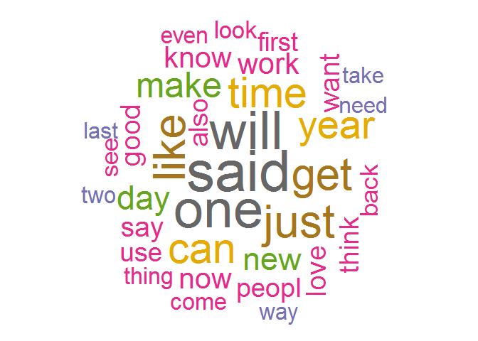

```r
c_tdm    = TermDocumentMatrix(s.corpus)
c_tdm    = rollup(c_tdm, 2, na.rm=TRUE, FUN = sum)
c_tdm.m  = as.matrix(c_tdm)
c_tdm.v  = sort(rowSums(c_tdm.m),decreasing=TRUE)
c_tdm.d  = data.frame(word = names(c_tdm.v),freq=c_tdm.v)
pal2 = brewer.pal(8,"Dark2")
wordcloud(c_tdm.d$word,c_tdm.d$freq, scale=c(5,.3),min.freq=1000,
          max.words=Inf, random.order=FALSE, rot.per=.15, colors=pal2)
```

### N-Gram Analysis

Since it is not very helplful to only look at single words when trying to predict text, I use N-gram analysis to get a better grasp of the way people use words. An n-gram is a contiguous sequence of ‘n’ items from a given text or in speech.

### Top Unigrams

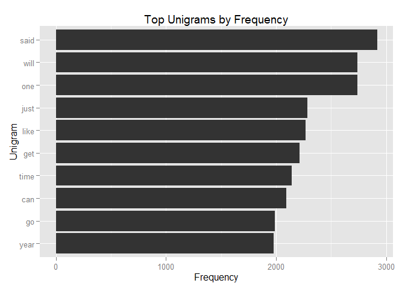

```r
g <- ggplot(uni.m, aes(x=reorder(String, Count), y=Count)) +
    geom_bar(stat = "identity") +  coord_flip() +
    theme(legend.title=element_blank()) +
    xlab("Unigram") + ylab("Frequency") +
    labs(title = "Top Unigrams by Frequency")
print(g)
```

### Top Bigrams

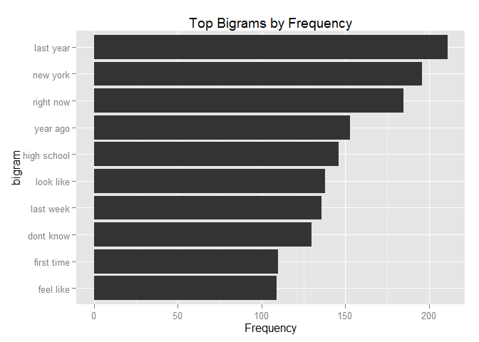

```r
g <- ggplot(bi.m, aes(x=reorder(String, Count), y=Count)) +
    geom_bar(stat = "identity") +  coord_flip() +
    theme(legend.title=element_blank()) +
    xlab("bigram") + ylab("Frequency") +
    labs(title = "Top Bigrams by Frequency")
print(g)
```

### Top Trigrams

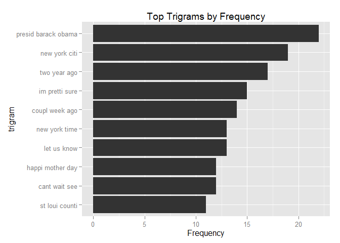

```r
g <- ggplot(tri.m, aes(x=reorder(String, Count), y=Count)) +
    geom_bar(stat = "identity") +  coord_flip() +
    theme(legend.title=element_blank()) +
    xlab("trigram") + ylab("Frequency") +
    labs(title = "Top Trigrams by Frequency")
print(g)
```

## Conclusions:

It is obvious that the data must be worked with efficiently for an alogrithim to work. Further, correctly stemming the document will provide better results. Sampling the data and n-gram analysis are a step in the right direction.